# EDA

# Introduction

Our task is to explore the data and prepare a 1/2 to 1 page written overview of our findings.

About the [data](https://www.ntsb.gov/_layouts/ntsb.aviation/index.aspx):

The NTSB aviation accident database contains information from 1962 and later about civil aviation accidents and selected incidents within the United States, its territories and possessions, and in international waters. Generally, a preliminary report is available online within a few days of an accident. Factual information is added when available, and when the investigation is completed, the preliminary report is replaced with a final description of the accident and its probable cause. Full narrative descriptions may not be available for dates before 1993, cases under revision, or where NTSB did not have primary investigative responsibility.

# Exploratory Data Analysis

## Load packages

```r
library(XML)
library(tidyverse)
library(lubridate)
theme_set(theme_minimal()) # set the ggplot theme
```

## Load the data

```r
# parse the xml file
data <- xmlParse("data/AviationData.xml")

# put all child nodes of the root node into a list
xml_data <- xmlToList(data)

# convert the list into a dataframe
df <- data.frame(matrix(unlist(xml_data$ROWS), nrow=length(xml_data$ROWS), byrow=TRUE))
```

### Clean the data

```r
# column names (can be found by inspecting the xml file)
colnames(df) <- c("EventID", "InvestigationType", "AccidentNumber", "EventDate", "Location", "Country", "Latitude", "Longitude", "AirportCode", "AirportName", "InjurySeverity", "AircraftDamage", "AircraftCategory", "RegistrationNumber", "Make", "Model", "AmateurBuilt", "NumberOfEngines", "EngineType", "FARDescription", "Schedule", "PurposeOfFlight", "AirCarrier", "TotalFatalInjuries", "TotalSeriousInjuries", "TotalMinorInjuries", "TotalUninjured", "WeatherCondition", "BroadPhaseOfFlight", "ReportStatus", "PublicationDate")
```

```r
# convert missing data to NA
df <- df %>% replace_with_na(replace = list(x = ""))
```

```
Error in replace_with_na(., replace = list(x = "")) :
  could not find function "replace_with_na"
```

Variable types have not been specified, but we can worry about that on a case-by-base basis.

## Visualize variable distributions

### Investigation Type

Evaluate the variables:

- InvestigationType (accident or incident)

The difference between accidents and incidents are described [here](https://www.eaa.org/eaa/aircraft-building/BuilderResources/next-steps-after-your-airplane-is-built/operating-articles/incidents-accidents-emergencies/aircraft-accident-and-incident-reporting).

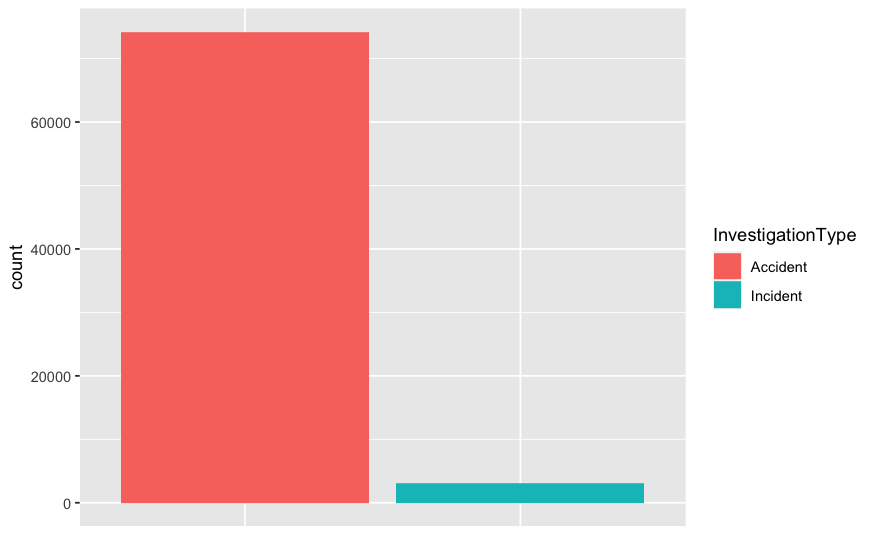

```r
ggplot(df, aes(x=InvestigationType, fill=InvestigationType)) + geom_bar() +
  theme(axis.title.x=element_blank(),
        axis.text.x=element_blank(),
        axis.ticks.x=element_blank())
```

### Time and location

Evaluate the variables:

- EventDate
- Location
- Country
- Latitude
- Longitude
- AirportCode
- AirportName

```r
# time series plot
tmp <- df %>%
  filter(InvestigationType == "Accident") %>% # remove incidents, which are always non-fatal
  mutate(InjuryType = ifelse(InjurySeverity %in% c("Non-Fatal", "Unavailable"), as.character(InjurySeverity), "Fatal")) %>%
  filter(!(InjuryType %in% c("Unavailable"))) %>% # remove missing values
  select(EventDate, InjuryType) %>%
  drop_na() %>%
  mutate(EventDate = mdy(EventDate),
         Year = year(EventDate)) %>%
  group_by(InjuryType, Year) %>%
  summarise(n = n())

# Plot accidents over time
ggplot(tmp,aes(Year, n, color=InjuryType)) +
  geom_line() +
  scale_x_continuous(limits = c(1982, 2016), breaks = seq(1982, 2015, 1)) +
  theme(axis.text.x = element_text(angle=90))
```

[output not shown]

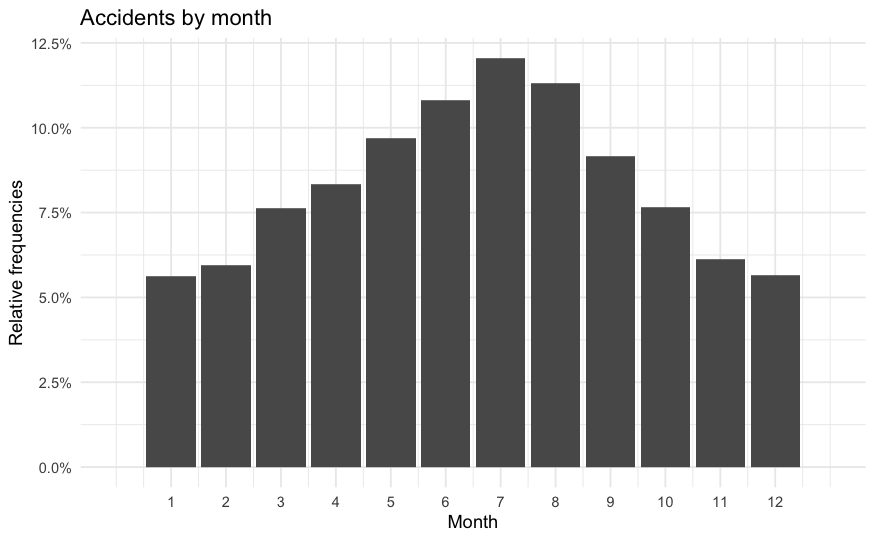

```r
tmp <- df %>%
  select(EventDate) %>%
  drop_na() %>%
  mutate(EventDate = mdy(EventDate),
         Month = month(EventDate)) %>%
  group_by(Month) %>%
  summarise(n = n()) %>%
  mutate(freq = n/(sum(n)))
# Since we notice a seasonal cycle, investigate the months
ggplot(tmp, aes(Month, freq)) +
  geom_bar(stat = "identity") +
  scale_y_continuous(labels=scales::percent) +
  ylab("Relative frequencies") +
  scale_x_continuous(limits=c(0,13), breaks = seq(1,12,1)) +
  ggtitle("Accidents by month")
```

```r
#library(maps)
library(RColorBrewer)
# library(forcats)

# remove the US and make some break points
tmp <- df %>%
  group_by(Country) %>%
  subset(!(Country %in% c("United States", ""))) %>%
  summarise(count = n()) %>%
  mutate(count_group = cut(count,
                           breaks = c(-Inf, 10, 25, 50, 100, 200, Inf),
                           labels = c("Fewer than 10", "10-25", "25-50", "50-100", "100-200", "More than 200")))

# Plot
world_map <- map_data("world") # world2
ggplot(tmp, aes(map_id = Country)) +
  geom_map(aes(fill = fct_rev(as.factor(count_group))), map = world_map) +
  expand_limits(x = world_map$long, y = world_map$lat) +
  theme_void() +
  coord_fixed() +
  scale_fill_manual(name = "Counts", values = rev(brewer.pal(6, name = "YlOrRd")))
```

```r
# latitude
tmp <- df %>%
  mutate_at(vars(Latitude), ~as.numeric(as.character(.))) %>%
  filter(InvestigationType == "Accident") %>% # remove incidents, which are always non-fatal
  mutate(InjuryType = ifelse(InjurySeverity %in% c("Non-Fatal", "Unavailable"), as.character(InjurySeverity), "Fatal")) %>%
  filter(!(InjuryType %in% c("Unavailable"))) # remove missing values

ggplot(tmp, aes(x=Latitude, after_stat(count), color=InjuryType, fill=InjuryType)) +
  geom_density(position="fill", alpha=0.2, adjust=3) +
  coord_flip() +
  ylab("Relative frequency")
```

[output not shown]

```r
# airport code
tmp <- df %>%
  filter(InvestigationType == "Accident") %>% # remove incidents, which are always non-fatal
  mutate(InjuryType = ifelse(InjurySeverity %in% c("Incident", "Non-Fatal", "Unavailable"), as.character(InjurySeverity), "Fatal")) %>%
  filter(!(InjuryType %in% c("Unavailable"))) %>% # remove undefined values
  select(AirportName, AircraftCategory, InjuryType) %>%
  mutate(AirportName = toupper(AirportName)) %>%
  mutate(AirportName = ifelse(grepl("PRIVATE", AirportName, fixed = T)==T, "PRIVATE", as.character(AirportName))) %>%
  mutate(AirportName = na_if(AirportName, "N/A")) %>%
  mutate(AirportName = na_if(AirportName, "NONE")) %>%
  drop_na() %>%
  group_by(InjuryType, AirportName) %>%
  summarise(n = n()) %>%
  mutate(Freq = n / sum(n)) %>%
  top_n(n=3)

ggplot(tmp, aes(x=reorder(AirportName,n), y=n)) +
  geom_bar(stat = "identity") +
  ylab("Count") +
  xlab("Make") +
  coord_flip() +
  facet_wrap(vars(InjuryType), scale = "free") +
  ggtitle("Airports with the most accidents")
```

### Severity

Evaluate the variables:

- InjurySeverity
- AircraftDamage

```r
# compare fatal vs non-fatal accidents
tmp <- df %>%
  filter(InvestigationType == "Accident") %>% # remove incidents, which are always non-fatal
  mutate(InjuryType = ifelse(InjurySeverity %in% c("", "Incident", "Non-Fatal", "Unavailable"), as.character(InjurySeverity), "Fatal")) %>%
  filter(!(InjuryType %in% c("", "Unavailable"))) # remove missing values

# plot
ggplot(tmp, aes(x=InjuryType, fill=InjuryType)) +
  geom_bar(aes(y = (..count..)/sum(..count..))) +
  scale_y_continuous(labels=scales::percent) +
  ylab("Relative frequencies") +
  theme(axis.title.x=element_blank(),
        axis.text.x=element_blank(),
        axis.ticks.x=element_blank()) +
  ggtitle("Types of Accidents")
```

```r
# If fatal, how many people died?
tmp <- tmp %>%
  filter(InjuryType %in% "Fatal") %>%
  mutate(Deaths = as.numeric(unlist(str_extract_all(InjurySeverity, "(?<=\\().+?(?=\\))"))))

# plot all fatalities. y-axis is sqrt transformation to show outliers
ggplot(tmp, aes(x=Deaths)) +
  geom_histogram(binwidth = 1) +
  scale_y_sqrt() +
  ggtitle("All fatalities")

# plot accidents with 1-10 fatalities
ggplot(tmp, aes(Deaths)) +
  geom_bar(stat = "count") +
  scale_x_continuous(limits=c(0,11), breaks = seq(1,10,1)) +
  ggtitle("Fatalities between 1-10")
```

[output not shown]

### Aircraft information

Evaluate the variables:

- AircraftCategory
- Make
- Model
- AmateurBuilt
- NumberOfEngines
- EngineType

```r
# Aircraft categories
tmp <- df %>%
  filter(!(AircraftCategory %in% c(""))) %>% # remove missing
  group_by(AircraftCategory) %>%
  summarise(n = n()) %>%
  mutate(Freq = n / sum(n))

# plot
ggplot(tmp, aes(x=reorder(AircraftCategory, Freq), Freq)) +
  geom_bar(stat = "identity") +
  scale_y_continuous(labels=scales::percent) +
  ylab("Relative frequencies") +
  xlab("Aircraft category") +
  coord_flip() +
  ggtitle("Aircraft categories")
```

```r
# Identify the top airplane and helicoptor companties associated with accidents

tmp <- df %>%
  filter(InvestigationType == "Accident") %>% # remove incidents, which are always non-fatal
  mutate(InjuryType = ifelse(InjurySeverity %in% c("Incident", "Non-Fatal", "Unavailable"), as.character(InjurySeverity), "Fatal")) %>%
  filter(!(InjuryType %in% c("Unavailable"))) %>% # remove undefined values
  select(Make, AircraftCategory, InjuryType) %>%
  filter(AircraftCategory %in% c("Airplane", "Helicopter")) %>%
  drop_na() %>%
  mutate(Make = ifelse(grepl("ROBINSON", Make, fixed = T)==T, "ROBINSON", as.character(Make))) %>% # consolidate duplicate names
  mutate(Make = toupper(Make)) %>% # consolidate duplicate names
  group_by(InjuryType, AircraftCategory, Make) %>%
  summarise(n = n()) %>%
  mutate(Freq = n / sum(n)) %>%
  top_n(n=5)

ggplot(tmp, aes(x=reorder(Make,n), y=n)) +
  geom_bar(stat = "identity") +
  ylab("Count") +
  xlab("Make") +
  coord_flip() +
  facet_grid(vars(AircraftCategory), vars(InjuryType), scale = "free") +
  ggtitle("Companies with the most accidents")
```

```r
# Identify the top airplane and helicoptor companties associated with accidents

tmp <- df %>%
  filter(InvestigationType == "Accident") %>% # remove incidents, which are always non-fatal
  mutate(InjuryType = ifelse(InjurySeverity %in% c("Incident", "Non-Fatal", "Unavailable"), as.character(InjurySeverity), "Fatal")) %>%
  filter(!(InjuryType %in% c("Unavailable"))) %>% # remove undefined values
  select(Make, Model, AircraftCategory, InjuryType) %>%
  filter(AircraftCategory %in% c("Airplane", "Helicopter")) %>%
  drop_na() %>%
  mutate(Make = ifelse(grepl("ROBINSON", Make, fixed = T)==T, "ROBINSON", as.character(Make))) %>% # consolidate duplicate names
  mutate(Make = toupper(Make)) %>% # consolidate duplicate names
  mutate(MakeModel = paste(Make, Model, sep = " ")) %>%
  group_by(InjuryType, AircraftCategory, MakeModel) %>%
  summarise(n = n()) %>%
  mutate(Freq = n / sum(n)) %>%
  top_n(n=5)

ggplot(tmp, aes(x=reorder(MakeModel,n), y=n)) +
  geom_bar(stat = "identity") +
  ylab("Count") +
  xlab("Make") +
  coord_flip() +
  facet_grid(vars(AircraftCategory), vars(InjuryType), scale = "free") +
  ggtitle("Models with the most accidents")
```

```r
# amateur built
tmp <- df %>%
  filter(InvestigationType == "Accident") %>% # remove incidents, which are always non-fatal
  mutate(InjuryType = ifelse(InjurySeverity %in% c("Non-Fatal", "Unavailable"), as.character(InjurySeverity), "Fatal")) %>%
  filter(!(InjuryType %in% c("Unavailable"))) %>% # remove undefined values
  select(AmateurBuilt, InjuryType) %>%
  drop_na()


ggplot(tmp, aes(x=AmateurBuilt, fill=InjuryType)) +
  geom_bar(stat = "count") +
  ylab("Count") +
  xlab("Amateur built") +
  ggtitle("Amateur vs. industrial builds")
```

```r
# number of engines
tmp <- df %>%
  mutate_all(na_if, "") %>%
  mutate(NumberOfEngines= case_when(
    NumberOfEngines == "0" ~ '0',
    NumberOfEngines == "1" ~ '1',
    NumberOfEngines == "2" ~ '2',
    NumberOfEngines == "4" ~ '3+',
    NumberOfEngines == "4" ~ '3+',
    NumberOfEngines == "18" ~ '3+',
    NumberOfEngines == "24" ~ '3+',
  )) %>%
  filter(InvestigationType == "Accident") %>% # remove incidents, which are always non-fatal
  mutate(InjuryType = ifelse(InjurySeverity %in% c("Non-Fatal", "Unavailable"), as.character(InjurySeverity), "Fatal")) %>%
  filter(!(InjuryType %in% c("Unavailable"))) %>% # remove undefined values
  select(NumberOfEngines, InjuryType) %>%
  drop_na() %>%
  group_by(InjuryType, NumberOfEngines) %>%
  summarise(n = n()) %>%
  mutate(freq = n/sum(n))

ggplot(tmp, aes(x=NumberOfEngines, y=freq)) +
  geom_bar(stat = "identity") +
  ylab("Relative frequency") +
  xlab("Number of engines") +
  facet_wrap("InjuryType") +
  ggtitle("Number of engines")
```

```r
#engine type
tmp <- df %>%
  filter(EngineType %in% c("Reciproacting", "Turbo Fan", "Turbo Jet", "Turbo Prop", "Turbo Shaft")) %>% # select the main players
  filter(InvestigationType == "Accident") %>% # remove incidents, which are always non-fatal
  mutate(InjuryType = ifelse(InjurySeverity %in% c("Non-Fatal", "Unavailable"), as.character(InjurySeverity), "Fatal")) %>%
  filter(!(InjuryType %in% c("Unavailable"))) %>% # remove undefined values
  select(EngineType, InjuryType) %>%
  drop_na() %>%
  group_by(InjuryType, EngineType) %>%
  summarise(n = n()) %>%
  mutate(freq = n/sum(n))

ggplot(tmp, aes(x=EngineType, y=freq)) +
  geom_bar(stat = "identity") +
  ylab("Relative frequency") +
  xlab("Engine type") +
  facet_wrap("InjuryType") +
  ggtitle("Type of engine")
```

### FAR ??

Evaluate the variables:

- FARDescription

```r
table(df$FARDescription)
```

skipping for now because I’m not sure what it means. But could be valuable for a RF model to predict fatality. Or a clustering model with or without the text sentiments.

### Logistics

Evaluate the variables:

- Schedule
- PurposeOfFlight
- AirCarrier

Schedule factor levels are: SCHD: “scheduled or commuter” NSCH: “non-scheduled or air taxi” carrier.

[Link](https://www.ntsb.gov/_layouts/ntsb.aviation/AviationDownloadDataDictionary.aspx) to definitions

```r
tmp <- df %>%
  mutate(Schedule= case_when(
    Schedule == "SCHD" ~ 'Scheduled or commuter',
    Schedule == "NSCH" ~ 'Non-scheduled or air taxi')) %>%
  filter(InvestigationType == "Accident") %>% # remove incidents, which are always non-fatal
  mutate(InjuryType = ifelse(InjurySeverity %in% c("Non-Fatal", "Unavailable"), as.character(InjurySeverity), "Fatal")) %>%
  filter(!(InjuryType %in% c("Unavailable"))) %>% # remove undefined values
  select(Schedule, InjuryType) %>%
  drop_na() %>%
  group_by(InjuryType, Schedule) %>%
  summarise(n = n()) %>%
  mutate(freq = n/sum(n))

ggplot(tmp, aes(x=Schedule, y=freq)) +
  geom_bar(stat = "identity") +
  ylab("Relative frequency") +
  xlab("Schedule") +
  facet_wrap("InjuryType") +
  ggtitle("Schedule")
```

```r
# purpose of flight
tmp <- df %>%
  filter(InvestigationType == "Accident") %>% # remove incidents, which are always non-fatal
  mutate(InjuryType = ifelse(InjurySeverity %in% c("Non-Fatal", "Unavailable"), as.character(InjurySeverity), "Fatal")) %>%
  filter(!(InjuryType %in% c("Unavailable"))) %>% # remove undefined values
  select(PurposeOfFlight, InjuryType) %>%
  drop_na() %>%
  group_by(PurposeOfFlight, InjuryType) %>%
  summarise(n = n()) %>%
  mutate(freq = n/sum(n))

ggplot(tmp, aes(x=InjuryType, y=freq, fill=InjuryType)) +
  geom_bar(stat = "identity") +
  ylab("Relative frequency") +
  xlab("Fatality") +
  facet_wrap("PurposeOfFlight") +
  ggtitle("PurposeOfFlight") +
  theme(axis.title.x=element_blank(),
      axis.text.x=element_blank(),
      axis.ticks.x=element_blank())
```

[output not shown]

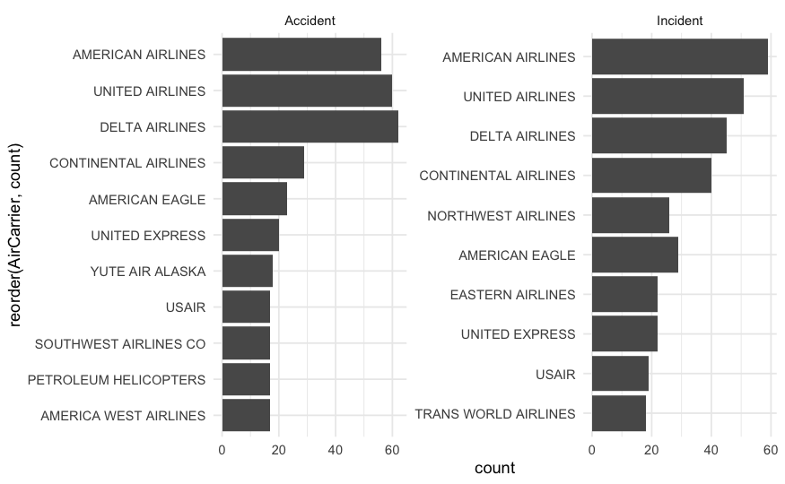

```r
# air carrier
remove <- c("\\*|\\(|\\)", ".*:", "INC", "LTD", ",", "\\.", "\\[|\\]", "EMS") # list of expressions to remove

tmp <- df %>%
  mutate(AirCarrier = toupper(as.character(AirCarrier))) %>%
  mutate(AirCarrier = str_remove_all(AirCarrier, paste(remove, collapse = "|"))) %>%
  mutate(AirCarrier = str_trim(AirCarrier, side = "both")) %>%
  mutate(AirCarrier = str_replace(AirCarrier, "AIR LINES", "AIRLINES")) %>%
  filter(!(AirCarrier %in% c(""))) %>%
  drop_na(AirCarrier) %>%
  group_by(InvestigationType, AirCarrier) %>%
  summarise(count=n()) %>%
  top_n(n=10)
ggplot(tmp, aes(x=reorder(AirCarrier, count), y=count)) +
  geom_bar(stat = "identity") +
  coord_flip() +
  facet_wrap(vars(InvestigationType), scales = "free")
```

Insights: Of the major airlines, American has the most incidents but the fewest accidents. Delta has the fewest incidents but the most accidents.

[figure not shown]

### Injuries

Evaluate the variables:

- TotalFatalInjuries
- TotalSeriousInjuries
- TotalMinorInjuries
- TotalUninjured

```r
# time-series of each injury type
tmp <- df %>%
  mutate_at(vars(TotalFatalInjuries, TotalSeriousInjuries, TotalMinorInjuries, TotalUninjured), ~as.numeric(as.character(.))) %>%
  pivot_longer(cols = starts_with("Total"), names_to = "Severity", values_to = "Individuals") %>%
  mutate(Severity = str_remove(Severity, "Total")) %>%
  mutate(EventDate = lubridate::mdy(EventDate)) %>%
  mutate(Year = lubridate::year(EventDate)) %>%
  group_by(Year, Severity) %>%
  summarise(n = sum(Individuals, na.rm = T))

# Plot injuries over time
ggplot(tmp,aes(x=Year, y=n, color=Severity)) +
  geom_line() +
  xlim(c(1982, 2015)) +

  theme(axis.text.x = element_text(angle=90))
```

### Flight details

Evaluate the variables:

- WeatherCondition
- BroadPhaseOfFlight
- ReportStatus

WeatherCondition levels: VMC: high visibility ("visual meteorologial conditions) IMC: insufficient visibility (instrument meteorological conditions) UNK: unknown

```r
# weather condition
tmp <- df %>%
  mutate(WeatherCondition= case_when(
    WeatherCondition == "VMC" ~ 'high visibility',
    WeatherCondition == "IMC" ~ 'low visibility')) %>%
  filter(InvestigationType == "Accident") %>% # remove incidents, which are always non-fatal
  mutate(InjuryType = ifelse(InjurySeverity %in% c("Non-Fatal", "Unavailable"), as.character(InjurySeverity), "Fatal")) %>%
  filter(!(InjuryType %in% c("Unavailable"))) %>% # remove undefined values
  select(WeatherCondition, InjuryType) %>%
  drop_na() %>%
  group_by(InjuryType, WeatherCondition) %>%
  summarise(n = n()) %>%
  mutate(freq = n/sum(n))

ggplot(tmp, aes(x=WeatherCondition, y=freq)) +
  geom_bar(stat = "identity") +
  ylab("Relative frequency") +
  xlab("Weather condition") +
  facet_wrap("InjuryType") +
  ggtitle("Weather condition")
```

[figure not shown]

don’t forget to: remove all redundancies add the lubridate package to the top fix the first time-series (should be an actual time series, not histograms)

idea: plot time series plots by state